# An Analysis of Street Trees in San Francisco

Brian Wang

Sep 2017

This dataset was obtained from (I think) Datazar a while back, in January 2017. The City of San Francisco maintains a more current version of this dataset on its open data portal here. https://data.sfgov.org/City-Infrastructure/Street-Tree-List/tkzw-k3nq/data.

By the description of the dataset on the website, this is a “List of dpw maintained street trees including: Planting date, species, and location”. Today, I’m going to explore this dataset to see what we can learn about trees in San Francisco.

## Data Import and Wrangling

```r
## Load required packages
library(lubridate)
library(stringr)
library(ggmap)
library(DT)
library(readr)
```

```r
library(tidyverse)
sf_trees <- read_csv('/Users/brianwang/Desktop/r/datasets/Street_Tree_List.csv',
                     col_types = cols(
                          TreeID = col_character(),
                          qLegalStatus = col_character(),
                          qSpecies = col_character(),
                          qAddress = col_character(),
                          SiteOrder = col_integer(),
                          qSiteInfo = col_character(),
                          PlantType = col_character(),
                          qCaretaker = col_character(),
                          qCareAssistant = col_character(),
                          PlantDate = col_character(),
                          DBH = col_integer(),
                          PlotSize = col_character(),
                          PermitNotes = col_character(),
                          XCoord = col_character(),
                          YCoord = col_character(),
                          Latitude = col_double(),
                          Longitude = col_double(),
                          Location = col_character()
                        ))
```

```r
## Count number of NAs in dataset
sapply(X = sf_trees, FUN = function(x) { sum(is.na(x)) })
```

```
##         TreeID   qLegalStatus       qSpecies       qAddress      SiteOrder
##              0             54              0           1490           1430
##      qSiteInfo      PlantType     qCaretaker qCareAssistant      PlantDate
##              0              0              0          73063          33048
##            DBH       PlotSize    PermitNotes         XCoord         YCoord
##          55277          42076          45225           2445           2445
##       Latitude      Longitude       Location
##           2445           2445          94702
```

```r
## Remove Location because it's basically a NULL variable
sf_trees$Location <- NULL
## Convert PlantDate to datetime
sf_trees$PlantDate <- mdy_hms(sf_trees$PlantDate, tz="America/Los_Angeles")
## Break qSpecies into scientific and common name
sf_trees <- sf_trees %>% extract(qSpecies,
                 into = c("Name_1", "Name_2"),
                 regex = "([A-z\\s]*) :: ([A-z\\s]*)")
## Extract Genus from Name_1
sf_trees <- sf_trees %>% extract(Name_1,
                 into = c("Genus"),
                 regex = "([A-z]*)", remove = FALSE)
## There's a weird error coming up
sf_trees$qSpecies <- NULL
## Turn empty strings into NAs
sf_trees$Genus[sf_trees$Genus == ''] <- NA
```

## Dataset Attributes

```r
dim(sf_trees)
```

```
## [1] 94702    19
```

There are a few trees that aren’t located in San Francisco technically (probably due to some data entry error, but the long/lat coordinates are not within the city limits). Because this is just a light analysis of this dataset, I’m just going to split the trees out into a separate dataset for now and not worry about them.

```r
## There are a few trees that aren't located in San Francisco technically, so I'm going to split these out into a separate dataset for now
problem_trees <- sf_trees %>%
  filter(!is.na(sf_trees$Latitude)) %>%
  filter(Latitude > 42 | Latitude < 37.6)

## Trees that are confirmed to either have NA lat/long or located in San Francisco
sf_trees <- sf_trees %>%
  filter((Latitude < 42 & Latitude > 37.6) | is.na(sf_trees$Latitude))
```

I’ll start by tabulating a lot of the categorical variables to understand how they’re related to the distribution of trees.

## Tabulation of categorical variables

### Legal status of trees in SF

```r
sf_trees %>% filter(!is.na(qLegalStatus)) %>%
  group_by(qLegalStatus) %>%
  summarise(Count = n(), Proportion = n() / nrow(sf_trees)) %>% arrange(desc(Count)) %>%
  datatable() %>% formatPercentage(3, 2)
```

|  | qLegalStatus | Count | Proportion |
| --- | --- | --- | --- |
| 1 | Permitted Site | 58599 | 0.619629696207083 |
| 2 | DPW Maintained | 22865 | 0.241776020133022 |
| 3 | Undocumented | 11167 | 0.1180805955314 |
| 4 | Significant Tree | 1102 | 0.0116526207822694 |
| 5 | Property Tree | 231 | 0.00244260925653742 |
| 6 | Section 143 | 198 | 0.00209366507703207 |
| 7 | Planning Code 138.1 required | 196 | 0.00207251694494084 |
| 8 | Private | 133 | 0.001406350784067 |
| 9 | Landmark tree | 26 | 0.00027492571718603 |

Most trees (61.96%) in San Francisco are planted through the permitting process (to become neighborhood trees), around 24.18% are maintained by the Department of Public Works, and the rest belong to other categories.

### Common types of trees in SF

```r
sf_trees %>% filter(!is.na(Name_2)) %>%
  group_by(Name_2) %>%
  summarise(Count = n()) %>% arrange(desc(Count)) %>% head() %>% datatable()
```

|  | Name_2 | Count |
| --- | --- | --- |
| 1 | Brisbane Box | 5598 |
| 2 | Sycamore | 4804 |
| 3 | New Zealand Xmas Tree | 4397 |
| 4 | Hybrid Strawberry Tree | 3242 |
| 5 | Swamp Myrtle | 3146 |
| 6 | Laurel Fig | 2806 |

### Common genus (genii?) of trees in SF

```r
sf_trees %>% filter(!is.na(sf_trees$Genus)) %>%
  group_by(Genus) %>%
  summarise(Count = n()) %>% arrange(desc(Count)) %>% head() %>% datatable()
```

|  | Genus | Count |
| --- | --- | --- |
| 1 | Lophostemon | 5598 |
| 2 | Platanus | 4811 |
| 3 | Prunus | 4686 |
| 4 | Metrosideros | 4397 |
| 5 | Pittosporum | 3784 |
| 6 | Ficus | 3603 |

### Common plant types (…?) of trees in SF

```r
sf_trees$PlantType[sf_trees$PlantType == 'tree'] <- 'Tree'
sf_trees %>% group_by(PlantType) %>%
  summarise(Count = n()) %>% arrange(desc(Count)) %>% head() %>% datatable()
```

|  | PlantType | Count |
| --- | --- | --- |
| 1 | Tree | 94378 |
| 2 | Landscaping | 193 |

Okay … um, well I’m glad that that most of the plant types in the dataset on San Francisco trees are trees. Thanks San Francisco.

### Common caretaker types and caretaker assistant types of trees in SF

```r
sf_trees %>% group_by(qCaretaker) %>%
  summarise(Count = n()) %>% arrange(desc(Count)) %>% head() %>% datatable()
```

|  | qCaretaker | Count |
| --- | --- | --- |
| 1 | Private | 68866 |
| 2 | DPW | 22292 |
| 3 | SFUSD | 985 |
| 4 | Rec/Park | 695 |
| 5 | Port | 687 |
| 6 | PUC | 257 |

Okay, so it turns out that this variable (`qCaretaker`) is probably pretty similar to the the `qLegalStatus` variable.

```r
sf_trees %>% filter(!is.na(sf_trees$qCareAssistant)) %>%
  group_by(qCareAssistant) %>%
  summarise(Count = n()) %>% arrange(desc(Count)) %>% head() %>% datatable()
```

|  | qCareAssistant | Count |
| --- | --- | --- |
| 1 | FUF | 20316 |
| 2 | DPW for City Agency | 765 |
| 3 | DPW | 206 |
| 4 | Cleary Bros. Landscape | 124 |
| 5 | SFUSD | 96 |
| 6 | Private | 59 |

FUF, short for Friends of the Urban Forest, is a 501(c)(3) nonprofit based in San Francisco that’s committed to promoting urban forestry in San Francisco and planting and caring for trees.

### Common sites of trees in SF

```r
sf_trees %>% group_by(qSiteInfo) %>%
  summarise(Count = n()) %>% arrange(desc(Count)) %>% head() %>% datatable()
```

|  | qSiteInfo | Count |
| --- | --- | --- |
| 1 | Sidewalk: Curb side : Cutout | 87053 |
| 2 | Median : Cutout | 2937 |
| 3 | Sidewalk: Property side : Cutout | 1063 |
| 4 | Front Yard : Yard | 1018 |
| 5 | Sidewalk: Property side : Yard | 724 |
| 6 | Sidewalk: Curb side : Yard | 581 |

Most trees are located on a cutout on the curbside of the sidewalk. There aren’t many yards in San Francisco I guess, which explains why there are so few “yard” trees.

Okay, so I think we have a pretty good understanding of the distribution of different categorical variables in this dataset. Before we move on, we can also quickly do some cross-tabulations to check out some interactions between categorical variables.

### Cross tabulation of legal status vs. caretaker of trees in SF

```r
sf_trees %>% group_by(qLegalStatus, qCaretaker) %>%
  tally() %>% arrange(desc(n)) %>% head(n=10) %>% spread(qCaretaker, n) %>% datatable()
```

|  | qLegalStatus | DPW | Port | Private | PUC | Rec/Park | SFUSD |
| --- | --- | --- | --- | --- | --- | --- | --- |
| 1 | DPW Maintained | 21922 |  |  |  |  | 678 |
| 2 | Permitted Site |  | 681 | 56681 | 231 | 395 |  |
| 3 | Planning Code 138.1 required |  |  | 195 |  |  |  |
| 4 | Section 143 |  |  | 197 |  |  |  |
| 5 | Significant Tree |  |  | 1002 |  |  |  |
| 6 | Undocumented |  |  | 10410 |  |  |  |

### Cross tabulation of common tree types vs. caretaker of trees in SF

```r
sf_trees %>% group_by(Name_2, qCaretaker) %>%
  tally() %>% arrange(desc(n)) %>% head(n=10) %>% spread(qCaretaker, n) %>% datatable()
```

|  | Name_2 | DPW | Private |
| --- | --- | --- | --- |
| 1 | Brisbane Box | 1871 | 3512 |
| 2 | Cherry Plum |  | 2386 |
| 3 | Hybrid Strawberry Tree |  | 2371 |
| 4 | New Zealand Xmas Tree |  | 2839 |
| 5 | Southern Magnolia |  | 1856 |
| 6 | Swamp Myrtle |  | 2097 |
| 7 | Sycamore | 2033 | 2268 |
| 8 |  |  | 13979 |

Looks like most “public” trees are Brisbane Boxes and Sycamores.

## Plotting frequency of tree planting over time

We have the date that trees were planted, so let’s map that over time to see if there are any interesting patterns.

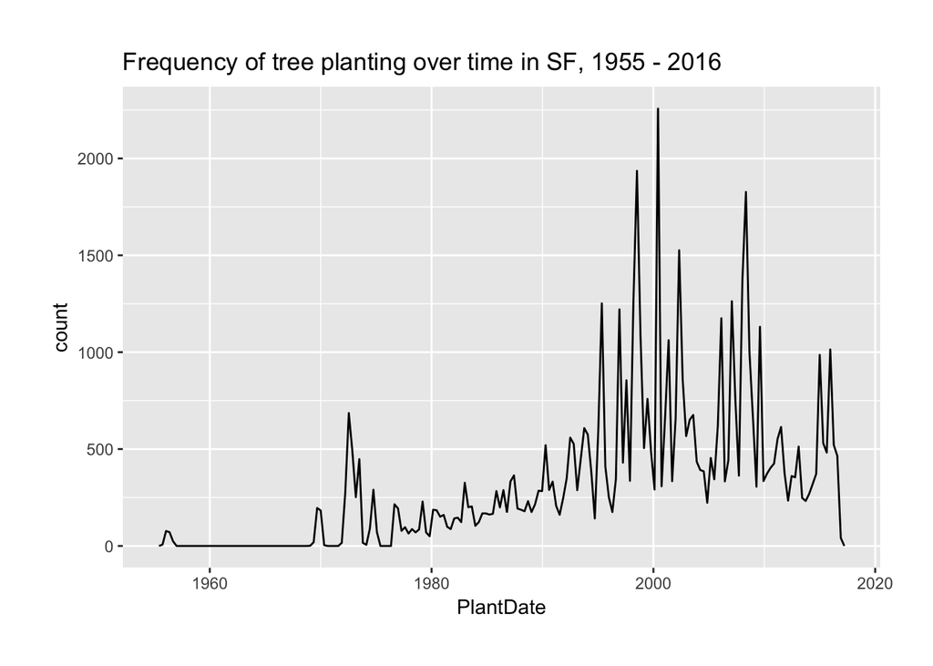

```r
sf_trees[!is.na(sf_trees$PlantDate),] %>% ggplot(aes(x=PlantDate)) +
  geom_freqpoly(binwidth = 10000000) +
  ggtitle("Frequency of tree planting over time in SF, 1955 - 2016") +
  theme(plot.margin = margin(1,1,1,1, "cm"))
```

What the plot shows us is that tree planting increased through the 80s and 90s and peaked arround the turn of the millenium, with another peak around 2009-2010. We can also plot the frequency of selected species of trees - let’s check out the following five trees.

```r
selected_trees <- c("Brisbane Box", "Sycamore", "New Zealand Xmas Tree", "Cherry Plum", "Hybrid Strawberry Tree")
```

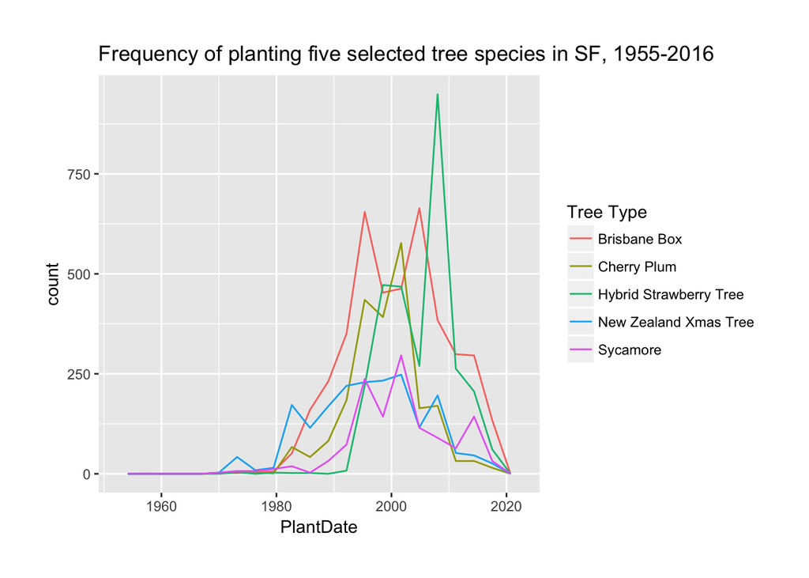

```r
sf_trees[!is.na(sf_trees$PlantDate),] %>%
  filter(Name_2 %in% selected_trees) %>%
  ggplot(aes(x=PlantDate)) +
  geom_freqpoly(binwidth=1e8, aes(group=Name_2, color=Name_2)) +
  labs(color="Tree Type") + ggtitle("Frequency of planting five selected tree species in SF, 1955-2016") +
  theme(plot.margin = margin(1,1,1,1, "cm"))
```

This is a pretty interesting frequency chart, because it shows us how planting of different types of trees has increased or decreased over time. Around the year 2000, the Brisbane Box, Cherry Plum, and Hybrid Strawberry Tree were all being planted a fair amount. However, the planting of hybrid strawberry trees spiked in the mid-late 2000s.

We know from our previous cross tab that the hybrid strawberry trees in this dataset are predominantly if not all privately cared for, so maybe there was some effort to push strawberry tree planting among private citizens.

Also, we know that the two most common types of trees that are managed by DPW are the Brisbane Box and Sycamore, and it’s interesting to see that there is some parallelism among the frequency plots of those two trees.

We also see that the New Zealand Xmas Tree had its heyday (at least, in terms of being the most popular tree) in the early 80s but it never experienced a huge surge in planting frequency compared to other trees after that. However, it stays the second most common “private”" type of tree.

## Mapping the density of trees in San Francisco

Let’s map the tree kernel density to get an idea of where trees are clustered in the city. Note that the kernel density is different from area density, which is what’s more commonly used in maps. To compute area density, I would have to partition the dataset into regions and compute the area density in each region. It’s more intuitive sometimes, especially if regions are already drawn out However, there may be cases in which it’s not always the best way of understanding where trees are most densely located, it depends on how the regions are partitioned out (see: Gerrymandering).

In contrast, the kernel density estimate is a smoothing of all of the points to estimate a probability density function over the entire region that will integrate to 1.

```r
## To map
map_trees <- sf_trees %>% filter(!is.na(sf_trees$Latitude))
```

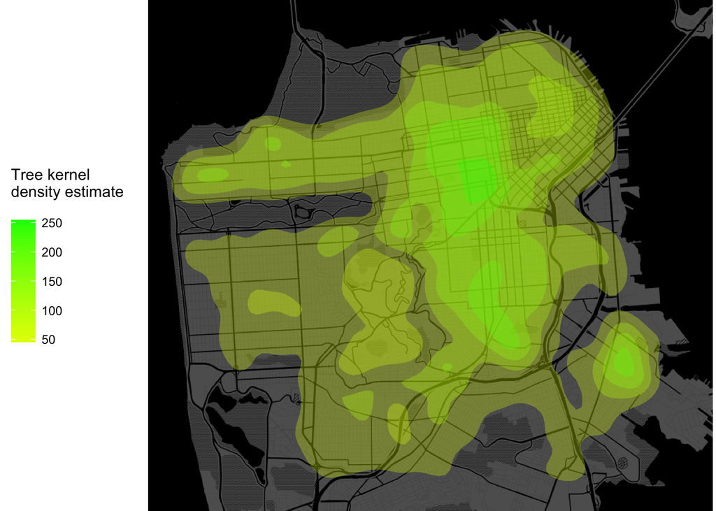

```r
qmplot(Longitude, Latitude, data = map_trees,
       source = "stamen", maptype = "toner-background",
       geom = "blank", darken = .7, legend = "left", zoom = 13) +
  stat_density2d(aes(fill = ..level..), geom = "polygon", alpha = .3) +
  scale_fill_gradient2('Tree kernel\ndensity estimate\n', low = "white", mid = "yellow", high = "green")
```

Looking at this map, it’s a bit interesting because it tells me that this dataset is clearly only counting city sidewalk trees - the entirety of Golden Gate park is left off the map. Looking into a few of the high density regions in the map - Hayes Valley, Hunters Point - I don’t see much green area on the map. So this is a pretty useful insight - this clearly doesn’t represent all the trees in San Francisco - only “city sidewalk” style trees - going back to the dataset, this is clear - DPW-maintained trees, as opposed to SF Parks & Rec maintained trees. Interesting, though, because Rec/Park is listed as a caretaker for some 600 or so city trees.

## Anyway, here are some final key takeaways, to wrap everything up:

- The most common tree is San Francisco is the Brisbane Box.
- Apparently there are a lot of sidewalk trees concentrated in Hayes Valley.
- Trees in San Francisco are managed by (at least) two separate departments, the Department of Public Works and the Department of Parks and Rec.